# R Notebook - Meta-analysis by Louise M. Alissa (Quality of Parental Care)

**ALISSA, L.M. Effect of reproductive site limitation on the intensity of sexual selection and the quality of paternal care: a meta-analysis. 2018. Dissertação (Mestrado) - Instituto de Biociências, Universidade de São Paulo, SP.**

The availability of reproductive sites is a major factor shaping the behavior of males and females in species with resource-based mating systems. Using a meta-analytic approach, we tested five predictions directly or indirectly derived from the mating system theory. We expected that reproductive site limitation would lead to: (1) intense male-male competition for resource possession; (2) high variance in male reproductive success, generating high values of opportunity for sexual selection; (3) high intensity of selection on male traits related to resource possession; (4) high sperm competition risk; and (5) low quality of paternal care. We compiled information from observational and experimental studies that compared the reproductive behavior of individuals of the same species under low and high reproductive site limitation. We found that, when reproductive sites are limited, there is a slight increase in male-male competition, with higher rates of nest takeover and agonistic interactions, and a slight increase in the selection gradient on male traits, with successful males tending to be larger than unsuccessful males. Reproductive site limitation has no consistent effect on the opportunity for sexual selection and on the sperm competition risk. However, territorial males invest more in gonads and lose less paternity when reproductive sites are limited. There is also no clear effect of reproductive site limitation on the quality of paternal care, but few studies have addressed this subject. Taken together, our findings indicate that predictions on how reproductive site limitation affects several aspects of resource-based mating systems have weak empirical support. These predictions do not consider the plasticity in the mating tactics of males and females, which make them too simplistic. Moreover, since the original proposition of the mating system theory, our understanding of sperm competition increased a lot. We now know that accurate predictions on the intensity and direction of sexual selection should take into account both pre- and post-copulatory processes. Finally, the interplay between sexual selection and parental care is complex, and the original framework of mating system theory does not provide sufficient elements to derive clear and taxonomically broad predictions.

Louise Alissa de Morais

e-mail: louisem.alissa@gmail.com

# Organizing

## Loading libraries, setting working directory and loading data set

### Setting the work directory

```r
setwd("C:/Users/louis/Dropbox/Masters_analyses-LMAlissa")
```

### Opening packages

```r
library(metafor)
library(ggplot2)
library(phytools)
library(geiger)
library(picante)
library(MuMIn)
library(car)
library(ape)
library(Hmisc)
library(bbmle)
library(miscTools)
```

### Cleanning possible masking objects

```r
rm(list=ls())
```

### Opening the .csv file

```r
dataset5 <- read.csv(file="basic_dataset5.csv", header=T, dec=".", sep=";")
```

### Looking the data structure

```r
head(dataset5)
```

|  | ES | nID | study | publication_year | species | phylo | class | order | taxon | mating_system | care | exploited_resource | study_type | nest_availability_difference | resource_facet_manipulated | PRED | pred | effect_over | response_variable | r | N |
| --- | --- | --- | --- | --- | --- | --- | --- | --- | --- | --- | --- | --- | --- | --- | --- | --- | --- | --- | --- | --- | --- |
| 1 | E. S. 01 | 46 | Werneck and Machado unpublished | unp | Magnispina neptunus | Magnispina_neptunus | Arachnida | Opiliones | 1_artro | polygamy | paternal | natural cavities in roadside banks | exp_lab | yes | quant | P6 | parental effort | parental | male foranging time (outside the nest) | -0.183000000 | 68 |
| 2 | E. S. 02 | 46 | Werneck and Machado unpublished | unp | Magnispina neptunus | Magnispina_neptunus | Arachnida | Opiliones | 1_artro | polygamy | paternal | natural cavities in roadside banks | exp_lab | yes | quant | P6 | parental effort | parental | filial canibalism | -0.006080404 | 37 |
| 3 | E. S. 03 | 46 | Werneck and Machado unpublished | unp | Magnispina neptunus | Magnispina_neptunus | Arachnida | Opiliones | 1_artro | polygamy | paternal | natural cavities in roadside banks | exp_lab | yes | quant | P6 | parental effort | parental | mean number of cannibalized eggs | 0.000000000 | 23 |
| 4 | E. S. 04 | 25 | Lehtonen and Lindstrom 2008 | 2008 | Archocentrus nigrofasciatus | Archocentrus_nigrofasciatus | Actinopterygii | Perciformes | 2_pisc | monogamy | biparental | cave, shelter, flowerpot | exp_field | yes | quant | P7 | offspring survival | offspring | brood survival (days) | -0.158000000 | 51 |
| 5 | E. S. 05 | 25 | Lehtonen and Lindstrom 2008 | 2008 | Archocentrus nigrofasciatus | Archocentrus_nigrofasciatus | Actinopterygii | Perciformes | 2_pisc | monogamy | biparental | cave, shelter, flowerpot | exp_field | yes | quant | P6 | parental effort | parental | attack rate towards potential offspring predators (attacks per mim) | 0.086000000 | 46 |
| 6 | E. S. 06 | 26 | Lindstrom 2001 | 2001 | Pomatoschistus minutus | Pomatoschistus_minutus | Actinopterygii | Perciformes | 2_pisc | polygamy | paternal | rock crevices, flowerpot | exp_lab | yes | quant | P7 | parental life spam | parental | mean male life spam (days) | 0.529000000 | 48 |

```r
tail(dataset5)
```

|  | ES | nID | study | publication_year | species | phylo | class | order | taxon | mating_system | care | exploited_resource | study_type | nest_availability_difference | resource_facet_manipulated | PRED | pred | effect_over | response_variable | r | N |
| --- | --- | --- | --- | --- | --- | --- | --- | --- | --- | --- | --- | --- | --- | --- | --- | --- | --- | --- | --- | --- | --- |
| 14 | E. S. 14 | 52 | Oliveira et al 2000 | 2000 | Parablennius sanguinolentus | Parablennius_sanguinolentus | Actinopterygii | Perciformes | 2_pisc | polygamy | paternal | natural crevices | obs | yes | qualit | P6 | parental effort | parental | nest cleanning | -0.2434557 | 24 |
| 15 | E. S. 15 | 15 | Garcia-Navas et al 2014 | 2014 | Cyanistes caeruleus | Cyanistes_caeruleus | Aves | Passeriformes | 4_aves | monogamy | biparental | tree hollows and nest box | exp_field | yes | quant | P7 | offspring survival | offspring | hatchling survival (%) | 0.6310000 | 6 |
| 16 | E. S. 16 | 15 | Garcia-Navas et al 2014 | 2014 | Cyanistes caeruleus | Cyanistes_caeruleus | Aves | Passeriformes | 4_aves | monogamy | biparental | tree hollows and nest box | exp_field | yes | quant | P7 | offspring survival | offspring | nestling survival (%) | 0.5390000 | 6 |
| 17 | E. S. 17 | 20 | Jacot et al 2009 | 2009 | Cyanistes caeruleus | Cyanistes_caeruleus | Aves | Passeriformes | 4_aves | polygamy | biparental | tree hollows and nest box | exp_field | yes | quant | P7 | offspring survival | offspring | mean hatchling number | -0.0880000 | 55 |
| 18 | E. S. 18 | 20 | Jacot et al 2009 | 2009 | Cyanistes caeruleus | Cyanistes_caeruleus | Aves | Passeriformes | 4_aves | polygamy | biparental | tree hollows and nest box | exp_field | yes | quant | P7 | offspring survival | offspring | mean fledgling number | -0.1470000 | 55 |
| 19 | E. S. 19 | 20 | Jacot et al 2009 | 2009 | Cyanistes caeruleus | Cyanistes_caeruleus | Aves | Passeriformes | 4_aves | polygamy | biparental | tree hollows and nest box | exp_field | yes | quant | P6 | parental effort | parental | mean numberof feeds per day by male | -0.1310000 | 30 |

```r
str(dataset5)
```

```
'data.frame':   19 obs. of  21 variables:
 $ ES                          : Factor w/ 19 levels "E. S. 01","E. S. 02",..: 1 2 3 4 5 6 7 8 9 10 ...
 $ nID                         : int  46 46 46 25 25 26 26 34 40 41 ...
 $ study                       : Factor w/ 11 levels "Downhower & Brown 1980",..: 11 11 11 4 4 5 5 6 8 9 ...
 $ publication_year            : Factor w/ 9 levels "1980","1985",..: 9 9 9 5 5 4 4 7 6 7 ...
 $ species                     : Factor w/ 9 levels "Archocentrus nigrofasciatus",..: 6 6 6 1 1 8 8 4 9 9 ...
 $ phylo                       : Factor w/ 9 levels "Archocentrus_nigrofasciatus",..: 6 6 6 1 1 8 8 4 9 9 ...
 $ class                       : Factor w/ 3 levels "Actinopterygii",..: 2 2 2 1 1 1 1 1 1 1 ...
 $ order                       : Factor w/ 4 levels " Scorpaeniformes",..: 2 2 2 4 4 4 4 1 4 4 ...
 $ taxon                       : Factor w/ 3 levels "1_artro","2_pisc",..: 1 1 1 2 2 2 2 2 2 2 ...
 $ mating_system               : Factor w/ 2 levels "monogamy","polygamy": 2 2 2 1 1 2 2 2 2 2 ...
 $ care                        : Factor w/ 2 levels "biparental","paternal": 2 2 2 1 1 2 2 2 2 2 ...
 $ exploited_resource          : Factor w/ 8 levels "cave, shelter, flowerpot",..: 3 3 3 1 1 6 6 5 5 5 ...
 $ study_type                  : Factor w/ 3 levels "exp_field","exp_lab",..: 2 2 2 1 1 2 2 2 2 3 ...
 $ nest_availability_difference: Factor w/ 2 levels "no","yes": 2 2 2 2 2 2 2 2 NA 2 ...
 $ resource_facet_manipulated  : Factor w/ 3 levels "dispo","qualit",..: 3 3 3 3 3 3 3 3 1 3 ...
 $ PRED                        : Factor w/ 2 levels "P6","P7": 1 1 1 2 1 2 2 1 2 2 ...
 $ pred                        : Factor w/ 3 levels "offspring survival",..: 2 2 2 1 2 3 3 2 2 2 ...
 $ effect_over                 : Factor w/ 2 levels "offspring","parental": 2 2 2 1 2 2 2 2 2 2 ...
 $ response_variable           : Factor w/ 18 levels "attack rate towards potential offspring predators (attacks per mim)",..: 7 4 11 2 1 10 10 16 14 12 ...
 $ r                           : num  -0.183 -0.00608 0 -0.158 0.086 ...
 $ N                           : int  68 37 23 51 46 48 48 60 14 67 ...
```

### Setting the rigth classes for variables

```r
dataset5$nID <- as.factor(dataset5$nID)
dataset5$publication_year <- as.factor(dataset5$publication_year)
str(dataset5)
```

```
'data.frame':   19 obs. of  21 variables:
 $ ES                          : Factor w/ 19 levels "E. S. 01","E. S. 02",..: 1 2 3 4 5 6 7 8 9 10 ...
 $ nID                         : Factor w/ 11 levels "15","20","25",..: 9 9 9 3 3 4 4 5 6 7 ...
 $ study                       : Factor w/ 11 levels "Downhower & Brown 1980",..: 11 11 11 4 4 5 5 6 8 9 ...
 $ publication_year            : Factor w/ 9 levels "1980","1985",..: 9 9 9 5 5 4 4 7 6 7 ...
 $ species                     : Factor w/ 9 levels "Archocentrus nigrofasciatus",..: 6 6 6 1 1 8 8 4 9 9 ...
 $ phylo                       : Factor w/ 9 levels "Archocentrus_nigrofasciatus",..: 6 6 6 1 1 8 8 4 9 9 ...
 $ class                       : Factor w/ 3 levels "Actinopterygii",..: 2 2 2 1 1 1 1 1 1 1 ...
 $ order                       : Factor w/ 4 levels " Scorpaeniformes",..: 2 2 2 4 4 4 4 1 4 4 ...
 $ taxon                       : Factor w/ 3 levels "1_artro","2_pisc",..: 1 1 1 2 2 2 2 2 2 2 ...
 $ mating_system               : Factor w/ 2 levels "monogamy","polygamy": 2 2 2 1 1 2 2 2 2 2 ...
 $ care                        : Factor w/ 2 levels "biparental","paternal": 2 2 2 1 1 2 2 2 2 2 ...
 $ exploited_resource          : Factor w/ 8 levels "cave, shelter, flowerpot",..: 3 3 3 1 1 6 6 5 5 5 ...
 $ study_type                  : Factor w/ 3 levels "exp_field","exp_lab",..: 2 2 2 1 1 2 2 2 2 3 ...
 $ nest_availability_difference: Factor w/ 2 levels "no","yes": 2 2 2 2 2 2 2 2 NA 2 ...
 $ resource_facet_manipulated  : Factor w/ 3 levels "dispo","qualit",..: 3 3 3 3 3 3 3 3 1 3 ...
 $ PRED                        : Factor w/ 2 levels "P6","P7": 1 1 1 2 1 2 2 1 2 2 ...
 $ pred                        : Factor w/ 3 levels "offspring survival",..: 2 2 2 1 2 3 3 2 2 2 ...
 $ effect_over                 : Factor w/ 2 levels "offspring","parental": 2 2 2 1 2 2 2 2 2 2 ...
 $ response_variable           : Factor w/ 18 levels "attack rate towards potential offspring predators (attacks per mim)",..: 7 4 11 2 1 10 10 16 14 12 ...
 $ r                           : num  -0.183 -0.00608 0 -0.158 0.086 ...
 $ N                           : int  68 37 23 51 46 48 48 60 14 67 ...
```

## Loanding and dealing with the phylogeny

### First, opening the file .tree (newik). The tree was constructed on Mesquite.

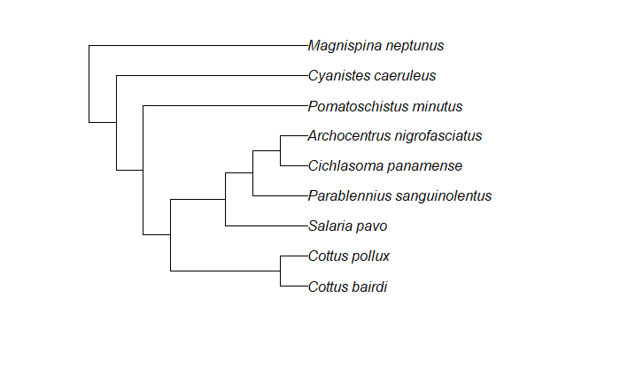

```r
tree5 <- read.tree('mytree5_mod.tre')
plot(tree5)
```

### Calculating the correlation matrix, with weighted values for relatedness

```r
tree5_mod <- compute.brlen(tree5, method="Grafen")
cor <- vcv(tree5_mod, corr =T)
```

### Cheking if every specie in the data is present in the tree

```r
spp <- data.frame(spp = unique(dataset5$phylo))
row.names(spp) <- spp$spp
```

```r
check.phylo <- name.check(tree5_mod, spp)
check.phylo
```

```
[1] "OK"
```

## Transforming r in Fisher’s Z

In our table we have values of r, here we transform to Z

```r
dataset5 <- escalc(measure="ZCOR", ri=r, ni=N, data=dataset5, append=TRUE)
attach(dataset5)
```

# Selecting the random-effects based on AICc

Randon variables: the effect size identity (id.mc), the article identity(nID), species (species) and the phylogenetic effect (phylo). Without moderators here.

### Creating an object for list each effect size

```r
id.pc <- as.factor(1:(length(dataset5$r)))
```

### Constructing models

```r
# id |--> AICc =  39.6314
m_randon1 <- rma.mv(yi=yi, V=vi, random = list(~ 1|id.pc), data=dataset5, method="ML")
summary(m_randon1)
```

```
Multivariate Meta-Analysis Model (k = 19; method: ML)

  logLik  Deviance       AIC       BIC      AICc
-17.4407   65.2126   38.8814   40.7703   39.6314

Variance Components:

            estim    sqrt  nlvls  fixed  factor
sigma^2    0.3299  0.5743     19     no   id.pc

Test for Heterogeneity:
Q(df = 18) = 296.5088, p-val < .0001

Model Results:

estimate      se    zval    pval    ci.lb   ci.ub
  0.2725  0.1409  1.9345  0.0530  -0.0036  0.5486  .

---
Signif. codes:  0 *** 0.001 ** 0.01 * 0.05 . 0.1   1
```

```r
# id + phylo |--> AICc = 41.3189
m_randon2 <- rma.mv(yi=yi, V=vi, random = list(~ 1|id.pc, ~1|phylo),R=list(phylo=cor), data=dataset5, method="ML")
summary(m_randon2)
```

```
Multivariate Meta-Analysis Model (k = 19; method: ML)

  logLik  Deviance       AIC       BIC      AICc
-16.8595   64.0501   39.7189   42.5522   41.3189

Variance Components:

            estim    sqrt  nlvls  fixed  factor    R
sigma^2.1  0.1462  0.3823     19     no   id.pc   no
sigma^2.2  0.3303  0.5747      9     no   phylo  yes

Test for Heterogeneity:
Q(df = 18) = 296.5088, p-val < .0001

Model Results:

estimate      se    zval    pval    ci.lb   ci.ub
  0.2676  0.3208  0.8343  0.4041  -0.3611  0.8963

---
Signif. codes:  0 *** 0.001 ** 0.01 * 0.05 . 0.1   1
```

```r
# id + species |--> AICc = 38.7766
m_randon3 <- rma.mv(yi=yi, V=vi, random = list(~ 1|id.pc, ~1|species), data=dataset5, method="ML")
summary(m_randon3)
```

```
Multivariate Meta-Analysis Model (k = 19; method: ML)

  logLik  Deviance       AIC       BIC      AICc
-15.5883   61.5078   37.1766   40.0099   38.7766

Variance Components:

            estim    sqrt  nlvls  fixed   factor
sigma^2.1  0.1156  0.3400     19     no    id.pc
sigma^2.2  0.2313  0.4810      9     no  species

Test for Heterogeneity:
Q(df = 18) = 296.5088, p-val < .0001

Model Results:

estimate      se    zval    pval    ci.lb   ci.ub
  0.2999  0.1869  1.6044  0.1086  -0.0665  0.6662

---
Signif. codes:  0 *** 0.001 ** 0.01 * 0.05 . 0.1   1
```

```r
# id + nID |--> AICc = 38.7606
m_randon4 <- rma.mv(yi=yi, V=vi, random = list(~ 1|id.pc, ~1|nID), data=dataset5, method="ML")
summary(m_randon4)
```

```
Multivariate Meta-Analysis Model (k = 19; method: ML)

  logLik  Deviance       AIC       BIC      AICc
-15.5803   61.4918   37.1606   39.9939   38.7606

Variance Components:

            estim    sqrt  nlvls  fixed  factor
sigma^2.1  0.1124  0.3353     19     no   id.pc
sigma^2.2  0.2299  0.4795     11     no     nID

Test for Heterogeneity:
Q(df = 18) = 296.5088, p-val < .0001

Model Results:

estimate      se    zval    pval   ci.lb   ci.ub
  0.3510  0.1744  2.0128  0.0441  0.0092  0.6928  *

---
Signif. codes:  0 *** 0.001 ** 0.01 * 0.05 . 0.1   1
```

```r
# id + specie + phylo |--> AICc = 42.0337
m_randon5 <- rma.mv(yi=yi, V=vi, random = list(~ 1|id.pc, ~1|species, ~1|phylo), R=list(phylo=cor), data=dataset5, method="ML")
summary(m_randon5)
```

```
Multivariate Meta-Analysis Model (k = 19; method: ML)

  logLik  Deviance       AIC       BIC      AICc
-15.5883   61.5078   39.1766   42.9543   42.0337

Variance Components:

            estim    sqrt  nlvls  fixed   factor    R
sigma^2.1  0.1156  0.3400     19     no    id.pc   no
sigma^2.2  0.2313  0.4810      9     no  species   no
sigma^2.3  0.0000  0.0000      9     no    phylo  yes

Test for Heterogeneity:
Q(df = 18) = 296.5088, p-val < .0001

Model Results:

estimate      se    zval    pval    ci.lb   ci.ub
  0.2999  0.1869  1.6044  0.1086  -0.0665  0.6662

---
Signif. codes:  0 *** 0.001 ** 0.01 * 0.05 . 0.1   1
```

```r
# id + nID + specie |--> AICc = 41.7347
m_randon6 <- rma.mv(yi=yi, V=vi, random = list(~ 1|id.pc, ~1|nID, ~1|species), data=dataset5, method="ML")
summary(m_randon6)
```

```
Multivariate Meta-Analysis Model (k = 19; method: ML)

  logLik  Deviance       AIC       BIC      AICc
-15.4388   61.2088   38.8776   42.6553   41.7347

Variance Components:

            estim    sqrt  nlvls  fixed   factor
sigma^2.1  0.1083  0.3291     19     no    id.pc
sigma^2.2  0.0864  0.2939     11     no      nID
sigma^2.3  0.1513  0.3890      9     no  species

Test for Heterogeneity:
Q(df = 18) = 296.5088, p-val < .0001

Model Results:

estimate      se    zval    pval    ci.lb   ci.ub
  0.3211  0.1845  1.7402  0.0818  -0.0405  0.6827  .

---
Signif. codes:  0 *** 0.001 ** 0.01 * 0.05 . 0.1   1
```

```r
# id + nID + phylo |--> AICc = 42.0178
m_randon7 <- rma.mv(yi=yi, V=vi, random = list(~ 1|id.pc, ~1|nID, ~1|phylo),R=list(phylo=cor), data=dataset5, method="ML")
summary(m_randon7)
```

```
Multivariate Meta-Analysis Model (k = 19; method: ML)

  logLik  Deviance       AIC       BIC      AICc
-15.5803   61.4918   39.1606   42.9384   42.0178

Variance Components:

            estim    sqrt  nlvls  fixed  factor    R
sigma^2.1  0.1124  0.3353     19     no   id.pc   no
sigma^2.2  0.2299  0.4795     11     no     nID   no
sigma^2.3  0.0000  0.0000      9     no   phylo  yes

Test for Heterogeneity:
Q(df = 18) = 296.5088, p-val < .0001

Model Results:

estimate      se    zval    pval   ci.lb   ci.ub
  0.3510  0.1744  2.0128  0.0441  0.0092  0.6928  *

---
Signif. codes:  0 *** 0.001 ** 0.01 * 0.05 . 0.1   1
```

```r
# id + nID + specie + phylo |--> AICc = 45.4929
m_randon8 <- rma.mv(yi=yi, V=vi, random = list(~ 1|id.pc, ~1|nID, ~1|species, ~1|phylo), R=list(phylo=cor), data=dataset5, method="ML")
summary(m_randon8)
```

```
Multivariate Meta-Analysis Model (k = 19; method: ML)

  logLik  Deviance       AIC       BIC      AICc
-15.4388   61.2088   40.8776   45.5998   45.4929

Variance Components:

            estim    sqrt  nlvls  fixed   factor    R
sigma^2.1  0.1083  0.3291     19     no    id.pc   no
sigma^2.2  0.0864  0.2939     11     no      nID   no
sigma^2.3  0.1513  0.3890      9     no  species   no
sigma^2.4  0.0000  0.0000      9     no    phylo  yes

Test for Heterogeneity:
Q(df = 18) = 296.5088, p-val < .0001

Model Results:

estimate      se    zval    pval    ci.lb   ci.ub
  0.3211  0.1845  1.7402  0.0818  -0.0405  0.6827  .

---
Signif. codes:  0 *** 0.001 ** 0.01 * 0.05 . 0.1   1
```

### Creating a table to compare models, looking for AICc

```r
ICtab(m_randon1, m_randon2, m_randon3, m_randon4, m_randon5, m_randon7, m_randon8, type= "AICc")
```

```
          dAICc df
m_randon4 0.0   3
m_randon3 0.0   3
m_randon1 0.9   2
m_randon2 2.6   3
m_randon7 3.3   4
m_randon5 3.3   4
m_randon8 6.7   5
```

# Performing - data set 5 - QUALITY OF PARENTAL CARE

## The meta-analytic model

Randon variables: the effect size identity, the article identity, species and the phylogenetic effect. Without moderators here.

```r
meta.pc.phylo <- rma.mv(yi=yi, V=vi, random = list(~ 1|id.pc, ~1|nID, ~1|species, ~1|phylo), R=list(phylo=cor) , data=dataset5, method="REML")
```

### Looking the results

```r
summary(meta.pc.phylo)
```

```
Multivariate Meta-Analysis Model (k = 19; method: REML)

  logLik  Deviance       AIC       BIC      AICc
-14.7079   29.4158   39.4158   43.8677   44.4158

Variance Components:

            estim    sqrt  nlvls  fixed   factor    R
sigma^2.1  0.1081  0.3287     19     no    id.pc   no
sigma^2.2  0.0820  0.2863     11     no      nID   no
sigma^2.3  0.1942  0.4407      9     no  species   no
sigma^2.4  0.0000  0.0000      9     no    phylo  yes

Test for Heterogeneity:
Q(df = 18) = 296.5088, p-val < .0001

Model Results:

estimate      se    zval    pval    ci.lb   ci.ub
  0.3199  0.1960  1.6319  0.1027  -0.0643  0.7041

---
Signif. codes:  0 *** 0.001 ** 0.01 * 0.05 . 0.1   1
```

### Overall effect and CI converted back to “r”

```r
predict(meta.pc.phylo, transf=transf.ztor)#  overall effect and CI converted back to "r"
```

```
   pred   ci.lb  ci.ub   cr.lb  cr.ub
 0.3094 -0.0642 0.6070 -0.7417 0.9208
```

### Basic forest plot (made with metafor package)

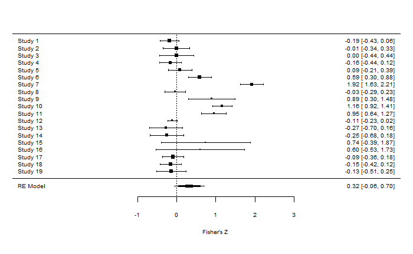

```r
forest(meta.pc.phylo, cex=.6, xlab="Fisher's Z")
```

## Heterogeinity

*Based in Nakagawa & Santos (2012)*

```r
s2m.pc <- sum(1/meta.pc.phylo$vi) * (meta.pc.phylo$k-1) / (sum(1/meta.pc.phylo$vi)^2 - sum((1/meta.pc.phylo$vi)^2))
s2m.pc #s^2_m variation within study
```

```
[1] 0.02242324
```

```r
s2t.pc <- sum(meta.pc.phylo$sigma2) + s2m.pc
s2t.pc #s^2_t variation total
```

```
[1] 0.4066491
```

### The total amount of variance

```r
total_I2.pc <- sum(meta.pc.phylo$sigma2)/s2t.pc
total_I2.pc # the "total" variation
```

```
[1] 0.9448585
```

### Proportion of variance from effect size id

```r
id.pc_I2 <- meta.pc.phylo$sigma2[1]/s2t.pc
id.pc_I2
```

```
[1] 0.2657226
```

### Proportion of variance from study id

```r
nID_I2 <- meta.pc.phylo$sigma2[2]/s2t.pc
nID_I2
```

```
[1] 0.2015643
```

### Proportion of variance from species id

```r
especies_I2 <- meta.pc.phylo$sigma2[3]/s2t.pc
especies_I2
```

```
[1] 0.4775715
```

### Proportion of variance from phylo

```r
phylo_I2 <- meta.pc.phylo$sigma2[4]/s2t.pc
phylo_I2
```

```
[1] 2.394955e-09
```

## The phylogenetic effect

Very low, in this case.

```r
H2.pc<-meta.pc.phylo$sigma2[4] / sum(meta.pc.phylo$sigma2)
H2.pc
```

```
[1] 2.534724e-09
```

## Qb

Testing if the mean effect is different in different taxa.

```r
mean_taxon <- rma.mv(yi=yi, V=vi, random = list(~ 1|id.pc, ~1|nID, ~1|species, ~1|phylo), R=list(phylo=cor) , data=dataset5, method="REML", mod= ~ taxon-1)
summary(mean_taxon)
```

```
Multivariate Meta-Analysis Model (k = 19; method: REML)

  logLik  Deviance       AIC       BIC      AICc
-12.2902   24.5804   38.5804   43.9885   52.5804

Variance Components:

            estim    sqrt  nlvls  fixed   factor    R
sigma^2.1  0.1060  0.3255     19     no    id.pc   no
sigma^2.2  0.0526  0.2293     11     no      nID   no
sigma^2.3  0.1231  0.3508      9     no  species   no
sigma^2.4  0.3465  0.5887      9     no    phylo  yes

Test for Residual Heterogeneity:
QE(df = 16) = 269.3096, p-val < .0001

Test of Moderators (coefficient(s) 1:3):
QM(df = 3) = 1.2199, p-val = 0.7482

Model Results:

              estimate      se     zval    pval    ci.lb   ci.ub
taxon1_artro   -0.0712  0.7534  -0.0946  0.9247  -1.5478  1.4053
taxon2_pisc     0.5082  0.4620   1.1001  0.2713  -0.3972  1.4136
taxon4_aves     0.0852  0.7353   0.1159  0.9077  -1.3559  1.5263

---
Signif. codes:  0 *** 0.001 ** 0.01 * 0.05 . 0.1   1
```

# Testing publication bias

## Egger’s regression

### Radial figure

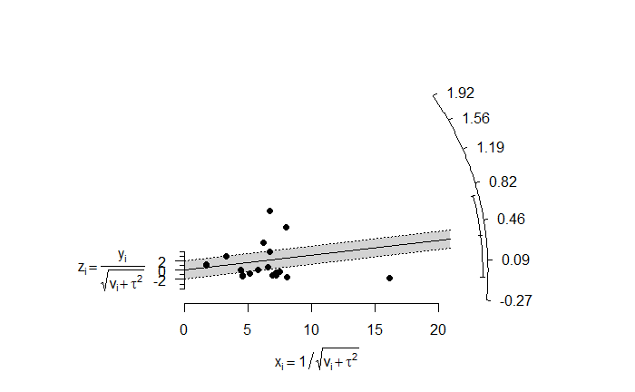

```r
# Egger's figure
radial.rma(meta.pc.phylo)
```

### Egger’s regression test

```r
s.e.pc <- sqrt(dataset5$vi)
precision.pc <- 1/s.e.pc
Egger.pc <- lm(dataset5$yi*precision.pc ~ precision.pc)
summary(Egger.pc)
```

```
Call:
lm(formula = dataset5$yi * precision.pc ~ precision.pc)

Residuals:
    Min      1Q  Median      3Q     Max
-2.8731 -2.4837 -1.6387  0.3386 11.4171

Coefficients:
             Estimate Std. Error t value Pr(>|t|)
(Intercept)   1.97740    2.17907   0.907    0.377
precision.pc -0.07573    0.31487  -0.241    0.813

Residual standard error: 4.079 on 17 degrees of freedom
Multiple R-squared:  0.003391,  Adjusted R-squared:  -0.05523
F-statistic: 0.05784 on 1 and 17 DF,  p-value: 0.8128
```

## Funnel Plot

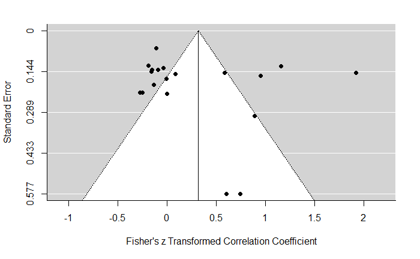

```r
# Basic funnel plot
funnel(meta.pc.phylo)
```

```r
#plot 1 ("plot")
plot(dataset5$yi,
     precision.pc,
     xlab="Fisher's Z",
     ylab="precision (1/s.e.)",
     cex=1.5,
     xlim=c(min(dataset5$yi, na.rm=T)-0.5,max(dataset5$yi, na.rm=T)+0.5),
     ylim=c(0,max(precision.pc, na.rm=T)*1.2))
abline(v=meta.pc.phylo[1], lwd=3)
```

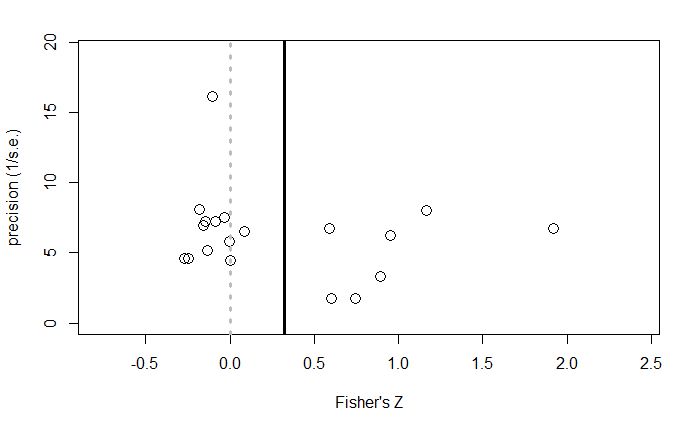

```r
abline(v=0, col=8, lwd=3, lty="dotted")
```

```r
#plot 2 ("ggplot")
dataset5$precision.pc <-precision.pc
funnel_5 <- ggplot(dataset5, aes(x=yi, y=precision.pc)) +
  geom_point(size=4, colour="gray30") +
  scale_shape(solid=FALSE) +
  xlab(expression("Fisher's "*italic(Z))) +
  ylab("precision (1/s.e.)") +
  theme_classic(base_size = 23)+
  geom_vline(xintercept=0, size=1.1, colour="gray", linetype = 1)+
  geom_vline(xintercept=0.1663, size=1.1, linetype = 1)+
  theme(axis.title.x=element_text(vjust=-0.1))+
  theme(axis.title.y=element_text(vjust=1.2))
#xlim(-1, 1) +
#ylim(0, 20) +
#theme(text=element_text(family="serif"))
```

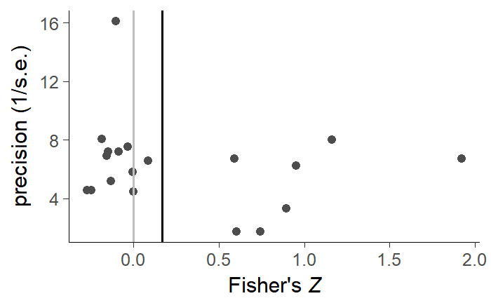

```r
funnel_5
```

# Moderators

## Type of methodological approach

Testing if differences between study methods (obs, exp_lab, exp_field) explain variance in data

```r
# study_type
meta.pc_mod1 <- rma.mv(yi=yi, V=vi, random = list(~ 1|id.pc, ~1|nID, ~1|species, ~1|phylo), R=list(phylo=cor) , data=dataset5, method="REML", mod= ~ study_type-1)
summary(meta.pc_mod1)
```

```
Multivariate Meta-Analysis Model (k = 19; method: REML)

  logLik  Deviance       AIC       BIC      AICc
-12.6285   25.2571   39.2571   44.6652   53.2571

Variance Components:

            estim    sqrt  nlvls  fixed   factor    R
sigma^2.1  0.1078  0.3283     19     no    id.pc   no
sigma^2.2  0.0880  0.2967     11     no      nID   no
sigma^2.3  0.2016  0.4490      9     no  species   no
sigma^2.4  0.0000  0.0000      9     no    phylo  yes

Test for Residual Heterogeneity:
QE(df = 16) = 210.4399, p-val < .0001

Test of Moderators (coefficient(s) 1:3):
QM(df = 3) = 4.0029, p-val = 0.2612

Model Results:

                     estimate      se    zval    pval    ci.lb   ci.ub
study_typeexp_field    0.0027  0.3388  0.0081  0.9935  -0.6613  0.6667
study_typeexp_lab      0.4432  0.3074  1.4416  0.1494  -0.1594  1.0457
study_typeobs          0.5552  0.3541  1.5678  0.1169  -0.1389  1.2493

---
Signif. codes:  0 *** 0.001 ** 0.01 * 0.05 . 0.1   1
```

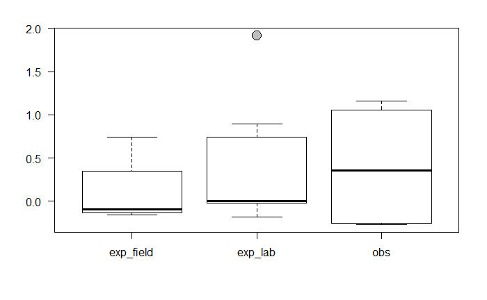

```r
plot(dataset5$study_type, dataset5$yi, las = 1, bty = "l", cex = 2, pch=21, bg=16)
```

```r
table(dataset5$study_type)
```

```
exp_field   exp_lab       obs
        8         7         4
```

## Type of mating system

Testing if differences between monogamy and polygamy mating systems explain variance in data

```r
# mating_system
meta.pc_mod2 <- rma.mv(yi=yi, V=vi, random = list(~ 1|id.pc, ~1|nID, ~1|species, ~1|phylo), R=list(phylo=cor) , data=dataset5, method="REML", mod= ~ mating_system-1)
summary(meta.pc_mod2)
```

```
Multivariate Meta-Analysis Model (k = 19; method: REML)

  logLik  Deviance       AIC       BIC      AICc
-13.5155   27.0309   39.0309   44.0302   47.4309

Variance Components:

            estim    sqrt  nlvls  fixed   factor    R
sigma^2.1  0.1020  0.3194     19     no    id.pc   no
sigma^2.2  0.0000  0.0000     11     no      nID   no
sigma^2.3  0.3303  0.5747      9     no  species   no
sigma^2.4  0.0000  0.0000      9     no    phylo  yes

Test for Residual Heterogeneity:
QE(df = 17) = 295.1674, p-val < .0001

Test of Moderators (coefficient(s) 1:2):
QM(df = 2) = 3.6464, p-val = 0.1615

Model Results:

                       estimate      se    zval    pval    ci.lb   ci.ub
mating_systemmonogamy    0.6604  0.3522  1.8751  0.0608  -0.0299  1.3508  .
mating_systempolygamy    0.1921  0.2291  0.8384  0.4018  -0.2570  0.6411

---
Signif. codes:  0 *** 0.001 ** 0.01 * 0.05 . 0.1   1
```

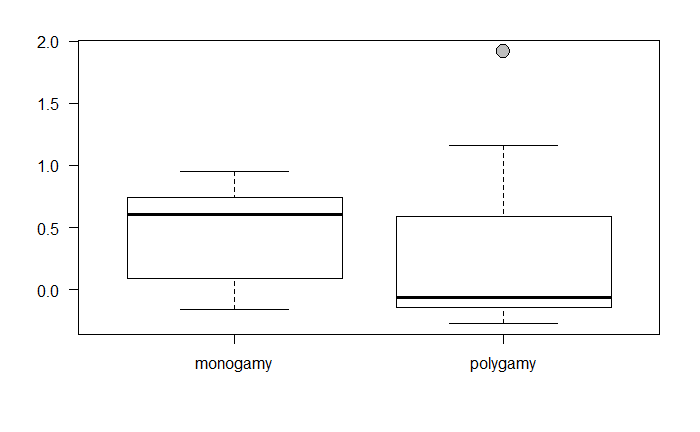

```r
plot(dataset5$mating_system, dataset5$yi, las = 1, bty = "l", cex = 2, pch=21, bg=16)
```

```r
table(dataset5$mating_system)
```

```
monogamy polygamy
       5       14
```

## Type of parental care

Testing if differences between parental care type (maternal, paternal, biparental, no_care) explain variance in data

```r
# parental care
meta.pc_mod3 <- rma.mv(yi=yi, V=vi, random = list(~ 1|id.pc, ~1|nID, ~1|species, ~1|phylo), R=list(phylo=cor) , data=dataset5, method="REML", mod= ~ care-1)
summary(meta.pc_mod3)
```

```
Multivariate Meta-Analysis Model (k = 19; method: REML)

  logLik  Deviance       AIC       BIC      AICc
-13.8691   27.7382   39.7382   44.7375   48.1382

Variance Components:

            estim    sqrt  nlvls  fixed   factor    R
sigma^2.1  0.1080  0.3286     19     no    id.pc   no
sigma^2.2  0.0759  0.2756     11     no      nID   no
sigma^2.3  0.2488  0.4988      9     no  species   no
sigma^2.4  0.0000  0.0000      9     no    phylo  yes

Test for Residual Heterogeneity:
QE(df = 17) = 292.5667, p-val < .0001

Test of Moderators (coefficient(s) 1:2):
QM(df = 2) = 2.3131, p-val = 0.3146

Model Results:

                estimate      se    zval    pval    ci.lb   ci.ub
carebiparental    0.2974  0.3595  0.8274  0.4080  -0.4071  1.0020
carepaternal      0.3295  0.2582  1.2761  0.2019  -0.1766  0.8355

---
Signif. codes:  0 *** 0.001 ** 0.01 * 0.05 . 0.1   1
```

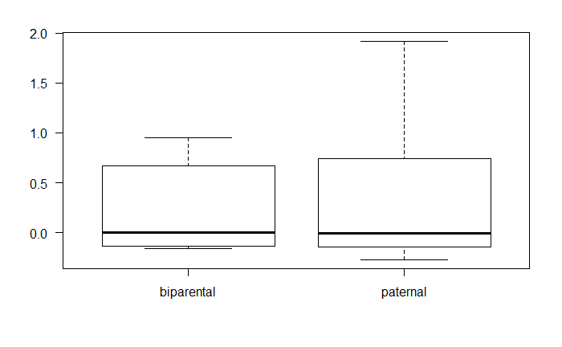

```r
plot(dataset5$care, dataset5$yi, las = 1, bty = "l", cex = 2, pch=21, bg=16)
```

```r
table(dataset5$care)
```

```
biparental   paternal
         8         11
```

## Costs over parental individual x offspring

Testing if there is difference between mean values of costs over parental and offspring individuals

```r
# parental care
meta.pc_mod4 <- rma.mv(yi=yi, V=vi, random = list(~ 1|id.pc, ~1|nID, ~1|species, ~1|phylo), R=list(phylo=cor) , data=dataset5, method="REML", mod= ~ effect_over-1)
summary(meta.pc_mod4)
```

```
Multivariate Meta-Analysis Model (k = 19; method: REML)

  logLik  Deviance       AIC       BIC      AICc
-14.0726   28.1451   40.1451   45.1444   48.5451

Variance Components:

            estim    sqrt  nlvls  fixed   factor    R
sigma^2.1  0.1189  0.3448     19     no    id.pc   no
sigma^2.2  0.1002  0.3165     11     no      nID   no
sigma^2.3  0.1506  0.3881      9     no  species   no
sigma^2.4  0.0000  0.0000      9     no    phylo  yes

Test for Residual Heterogeneity:
QE(df = 17) = 233.0963, p-val < .0001

Test of Moderators (coefficient(s) 1:2):
QM(df = 2) = 3.4765, p-val = 0.1758

Model Results:

                      estimate      se    zval    pval    ci.lb   ci.ub
effect_overoffspring    0.1646  0.2835  0.5806  0.5615  -0.3910  0.7202
effect_overparental     0.3807  0.2043  1.8634  0.0624  -0.0197  0.7810  .

---
Signif. codes:  0 *** 0.001 ** 0.01 * 0.05 . 0.1   1
```

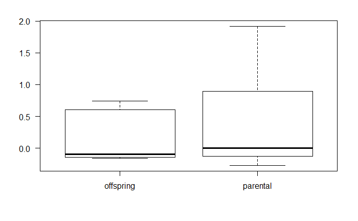

```r
plot(dataset5$effect_over, dataset5$yi, las = 1, bty = "l", cex = 2, pch=21, bg=16)
```

```r
table(dataset5$effect_over)
```

```
offspring  parental
        6        13
```

# Making a better forest plot

```r
mean.effect <- as.data.frame(matrix(t(mean.effect),nrow=1),stringsAsFactors=FALSE)
class(mean.effect)
```

```
[1] "data.frame"
```

```r
df5.5$yi <- as.character(df5.5$yi)
df5.5$CILB <- as.character(df5.5$CILB)
df5.5$CIUB <- as.character(df5.5$CIUB)
```

```r
df5.5$yi <- as.numeric(df5.5$yi)
df5.5$CILB <- as.numeric(df5.5$CILB)
df5.5$CIUB <- as.numeric(df5.5$CIUB)
```

```r
highlight <- subset(df5.5, ES=="Mean effect size")
```

Now, creating the plot

```r
myplot_5 <- ggplot(df5.5, aes(x=ES)) +
  geom_hline(aes(yintercept=0), linetype="dashed", color="gray", lwd=1) +
  geom_linerange(aes(x=ES, ymin=CILB, ymax=CIUB),col="grey50", lwd=1, alpha=0.7) +
  geom_linerange(aes(x=ES, ymin=CILB, ymax=CIUB), data=highlight, colour="black") +
  geom_point(aes(y=yi, size=yi), shape = 21, fill="grey50", col="grey50") +
  geom_point(aes(y=yi, size=yi), data=highlight, colour="black") +
  scale_size_continuous(range = c(1,5), name="Effect size Zr") +
  scale_x_discrete(limits = rev(levels(df5.5$ES)))+
  ylab(expression(Effect~Size~italic(Zr)))+
  xlab("")+
  theme_bw()+
  coord_flip()+
  guides(fill= guide_legend(override.aes = list(size=5)),
         size = guide_legend(override.aes = list(fill = "gray40")))+
  theme(panel.border = element_blank(),
        panel.grid.major = element_blank(),
        panel.grid.minor = element_blank(),
        axis.text.x = element_text(size=12),
        axis.text.y = element_text(size=10),
        axis.line = element_line(colour = "black"),
        legend.position = "none")
```

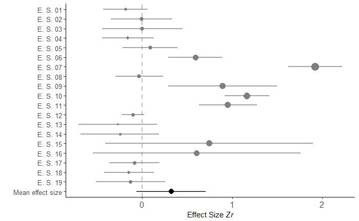

```r
myplot_5
```